# Analysis of neuropsych data

```r
# for replication purposes
set.seed(107)
source('~/ncr_notebooks/baseline_prediction/src/aux_functions.R')
# Philip pre-selected which structural scans to use
gf_fname = '~/data/baseline_prediction/gf_updated_02152017_3.csv'
gf = read.csv(gf_fname)
group_var = 'DX2'
idx = gf$BASELINE == 'BASELINE'
gf = gf[idx,]
eval(parse(text=sprintf('groups = gf$\"%s\"', group_var)))
groups_orig = groups
```

Now it’s a matter of selecting the variables we want to test. Because there are too many variables with NAs, and right now I don’t have an intuition of whether imputation or removing subjects would work best. Let’s do this within domain first, and evaluate in a per-domain basis.

# IQ

Philip says that VIQ and PIQ make up FSIQ. So, let’s run them separately:

```r
conn_na = colSums(is.na(ldata)) / nrow(ldata)
phen_vars = c('VIQ', 'PIQ')
keep_me = c()
for (v in phen_vars) {
  keep_me = c(keep_me, which(colnames(gf) == v))
}
ldata_orig = gf[, keep_me]
groups_orig = groups
```

First we try some imputation:

```r
ldata = ldata_orig
groups = groups_orig
preProcValues <- preProcess(ldata, method = c("medianImpute"))
ldata <- predict(preProcValues, ldata)
ncv = 5
nrepeatcv = 2
nsplits = 5
train_test_ratio = .85
root_fname = '~/tmp/VIQPIQ_medianImputed_NVvsADHD'
# saving output
library(caret)
sink(sprintf('%s.log', root_fname), append=FALSE, split=TRUE)
ncpus <- detectBatchCPUs()
njobs = ncpus - 1
run_models = c('rndForest', 'lr', 'rsvm', 'xgb') # c('rndForest', 'lr', 'lsvm', 'rsvm', 'xgb', 'gbm')
inTrain = createDataPartition(y = groups,
                              times= nsplits,
                              p=train_test_ratio)
metric = "ROC"
default_preproc = c("center", 'scale')
default_options = c()
ctrl_cv <- trainControl(method = "repeatedcv",
                        number = ncv,
                        repeats = nrepeatcv,
                        classProbs = TRUE,
                        returnData = FALSE,
                        summaryFunction = twoClassSummary,
                        preProcOptions = default_options,
                        search='grid')
source('~/ncr_notebooks/baseline_prediction/src/do_classification.R')
```

```
[1] 7

Working on split 1 of 5
Running random forests
   user  system elapsed
 40.838   0.902   1.204

Running logistic regression
   user  system elapsed
  2.322   0.799   1.412

Running RBF SVM
```

```
kernlab class prediction calculations failed; returning NAskernlab class probability calculations failed; returning NAsThere were missing values in resampled performance measures.
```

```
   user  system elapsed
133.393   3.532  33.905

Running XGBoost
   user  system elapsed
144.680   3.389  27.024

Working on split 2 of 5
Running random forests
   user  system elapsed
 46.759   1.737   1.602

Running logistic regression
```

```
There were missing values in resampled performance measures.
```

```
   user  system elapsed
  2.724   0.961   1.508

Running RBF SVM
```

```
kernlab class prediction calculations failed; returning NAskernlab class probability calculations failed; returning NAsThere were missing values in resampled performance measures.
```

```
maximum number of iterations reached 3.15577e-05 3.155762e-05   user  system elapsed
145.455   3.489  36.586

Running XGBoost
   user  system elapsed
158.794   3.737  23.308

Working on split 3 of 5
Running random forests
   user  system elapsed
 22.284   1.083   1.386

Running logistic regression
   user  system elapsed
  2.401   0.848   1.302

Running RBF SVM
   user  system elapsed
134.474   3.160  36.142

Running XGBoost
   user  system elapsed
124.496   2.802  25.983

Working on split 4 of 5
Running random forests
   user  system elapsed
 69.209   2.191   1.458

Running logistic regression
   user  system elapsed
  2.498   0.871   1.447

Running RBF SVM
```

[output not shown]

```
   user  system elapsed
140.098   3.466  35.688

Running XGBoost
   user  system elapsed
159.320   3.359  23.459

Working on split 5 of 5
Running random forests
   user  system elapsed
 22.594   0.995   1.299

Running logistic regression
   user  system elapsed
  2.626   0.964   1.289

Running RBF SVM
```

```
kernlab class prediction calculations failed; returning NAskernlab class probability calculations failed; returning NAsThere were missing values in resampled performance measures.
```

```
   user  system elapsed
141.733   3.106  37.406

Running XGBoost
   user  system elapsed
141.761   2.922  23.653
```

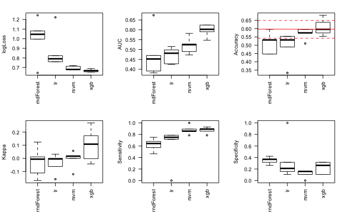

```r
source('~/ncr_notebooks/baseline_prediction/src/do_metrics_plots.R')
```

```r
sink()
```

We should try doing the imputation from within the cross-validation later. For now, let’s try just removing subjects with NAs:

```r
ldata = ldata_orig
groups = groups_orig
keep_me = rowSums(is.na(ldata)) == 0
ldata = ldata[keep_me, ]
groups = groups[keep_me]
root_fname = '~/tmp/VIQPIQ_NAremoved_NVvsADHD'
sink(sprintf('%s.log', root_fname), append=FALSE, split=TRUE)
inTrain = createDataPartition(y = groups,
                              times= nsplits,
                              p=train_test_ratio)
source('~/ncr_notebooks/baseline_prediction/src/do_classification.R')
```

```
[1] 7

Working on split 1 of 5
Running random forests
   user  system elapsed
  1.251   0.284   1.147

Running logistic regression
   user  system elapsed
  2.129   0.746   1.391

Running RBF SVM
   user  system elapsed
 99.809   3.241  27.378

Running XGBoost
   user  system elapsed
 80.099   2.227  21.925

Working on split 2 of 5
Running random forests
   user  system elapsed
 74.570   2.518   1.249

Running logistic regression
   user  system elapsed
  2.494   0.824   1.468

Running RBF SVM
   user  system elapsed
140.994   3.846  40.147

Running XGBoost
   user  system elapsed
163.840   4.192  26.755

Working on split 3 of 5
Running random forests
   user  system elapsed
 22.354   0.833   1.190
```

[output cut: 31 more lines]

```
Running random forests
   user  system elapsed
 44.728   1.614   1.291

Running logistic regression
   user  system elapsed
  1.870   0.661   1.477

Running RBF SVM
   user  system elapsed
133.037   3.709  35.775

Running XGBoost
   user  system elapsed
158.829   4.079  24.333
```

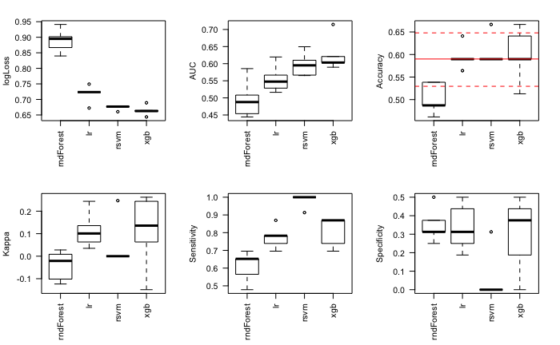

```r
source('~/ncr_notebooks/baseline_prediction/src/do_metrics_plots.R')
```

```r
sink()
```

And now we try FSIQ by itself:

```r
phen_vars = c('FSIQ')
keep_me = c()
for (v in phen_vars) {
  keep_me = c(keep_me, which(colnames(gf) == v))
}
ldata_orig = gf[, keep_me]
ldata_orig = as.data.frame(ldata_orig)
```

```r
ldata = ldata_orig
groups = groups_orig
preProcValues <- preProcess(ldata, method = c("medianImpute"))
ldata <- predict(preProcValues, ldata)
root_fname = '~/tmp/FSIQ_medianImputed_NVvsADHD'
sink(sprintf('%s.log', root_fname), append=FALSE, split=TRUE)
run_models = c('rndForest', 'lr')  # rsvm was taking a long-ass time, and xgb was crapping out
inTrain = createDataPartition(y = groups,
                              times= nsplits,
                              p=train_test_ratio)
source('~/ncr_notebooks/baseline_prediction/src/do_classification.R')
```

```
[1] 7

Working on split 1 of 5
Running random forests
   user  system elapsed
  5.503   1.857   0.990

Running logistic regression
   user  system elapsed
  1.811   0.595   1.183

Working on split 2 of 5
Running random forests
   user  system elapsed
  2.142   0.729   0.935

Running logistic regression
   user  system elapsed
  1.634   0.514   1.168

Working on split 3 of 5
Running random forests
   user  system elapsed
  2.038   0.673   0.973

Running logistic regression
   user  system elapsed
  1.892   0.618   1.199

Working on split 4 of 5
Running random forests
   user  system elapsed
  2.121   0.699   0.991

Running logistic regression
   user  system elapsed
  1.892   0.597   1.214

Working on split 5 of 5
Running random forests
   user  system elapsed
  2.192   0.735   0.940

Running logistic regression
   user  system elapsed
  1.800   0.590   1.325
```

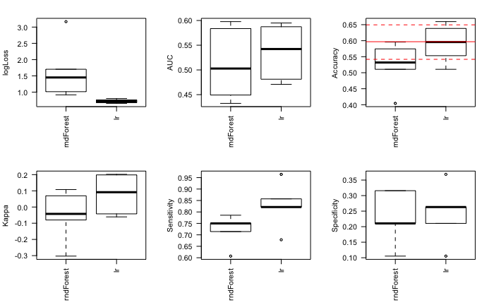

```r
source('~/ncr_notebooks/baseline_prediction/src/do_metrics_plots.R')
```

```r
sink()
```

And subjects removed:

```r
ldata = ldata_orig
groups = groups_orig
keep_me = rowSums(is.na(ldata)) == 0
ldata = as.data.frame(ldata[keep_me, ])
groups = groups[keep_me]
root_fname = '~/tmp/FSIQ_NAremoved_NVvsADHD'
run_models = c('rndForest', 'lr')  # rsvm was taking a long-ass time, and xgb was crapping out
sink(sprintf('%s.log', root_fname), append=FALSE, split=TRUE)
inTrain = createDataPartition(y = groups,
                              times= nsplits,
                              p=train_test_ratio)
source('~/ncr_notebooks/baseline_prediction/src/do_classification.R')
```

```
[1] 7

Working on split 1 of 5
Running random forests
   user  system elapsed
 99.328   1.118   1.012

Running logistic regression
   user  system elapsed
  2.081   0.643   1.380

Working on split 2 of 5
Running random forests
   user  system elapsed
  2.469   0.862   1.164

Running logistic regression
   user  system elapsed
  2.173   0.671   1.358

Working on split 3 of 5
Running random forests
   user  system elapsed
  2.353   0.800   1.043

Running logistic regression
   user  system elapsed
  2.105   0.661   1.322

Working on split 4 of 5
Running random forests
   user  system elapsed
  2.597   0.829   1.161

Running logistic regression
   user  system elapsed
  1.930   0.605   1.298

Working on split 5 of 5
Running random forests
   user  system elapsed
  2.375   0.771   1.060

Running logistic regression
   user  system elapsed
  2.208   0.672   1.332
```

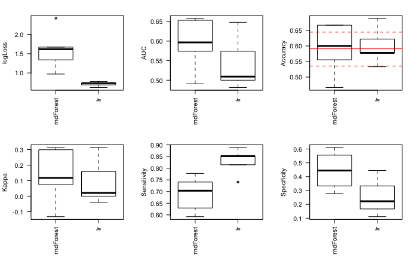

```r
source('~/ncr_notebooks/baseline_prediction/src/do_metrics_plots.R')
```

```r
sink()
```

# CPT

```r
phen_vars = c('N_of_omissions', 'N_commissions',
              'hit_RT', 'hit_RT_SE', 'variability_of_SE', 'N_perservations',
              'hit_RT_block_change', 'hit_RT_SE_block_change',
              'hit_RT_ISI_change', 'hit_RT_SE_ISI_change')
keep_me = c()
for (v in phen_vars) {
  keep_me = c(keep_me, which(colnames(gf) == v))
}
ldata_orig = gf[, keep_me]
```

```r
ldata = ldata_orig
groups = groups_orig
preProcValues <- preProcess(ldata, method = c("medianImpute"))
ldata <- predict(preProcValues, ldata)
root_fname = '~/tmp/CPT_medianImputed_NVvsADHD'
# saving output
sink(sprintf('%s.log', root_fname), append=FALSE, split=TRUE)
run_models = c('rndForest', 'lr', 'rsvm', 'xgb') # c('rndForest', 'lr', 'lsvm', 'rsvm', 'xgb', 'gbm')
inTrain = createDataPartition(y = groups,
                              times= nsplits,
                              p=train_test_ratio)
metric = "ROC"
default_preproc = c("center", 'scale')
default_options = c()
ctrl_cv <- trainControl(method = "repeatedcv",
                        number = ncv,
                        repeats = nrepeatcv,
                        classProbs = TRUE,
                        returnData = FALSE,
                        summaryFunction = twoClassSummary,
                        preProcOptions = default_options,
                        search='grid')
source('~/ncr_notebooks/baseline_prediction/src/do_classification.R')
```

```
[1] 7

Working on split 1 of 5
Running random forests
   user  system elapsed
  6.553   1.606   2.199

Running logistic regression
   user  system elapsed
  4.110   1.262   1.505

Running RBF SVM
   user  system elapsed
 49.528   3.171  11.698

Running XGBoost
   user  system elapsed
237.130   4.700  40.869

Working on split 2 of 5
Running random forests
   user  system elapsed
 43.540   1.869   2.425

Running logistic regression
   user  system elapsed
  4.421   1.680   1.683

Running RBF SVM
   user  system elapsed
 68.064   3.486  14.090

Running XGBoost
   user  system elapsed
250.345   4.614  45.920

Working on split 3 of 5
Running random forests
   user  system elapsed
 46.905   1.966   2.524
```

[output cut: 31 more lines]

```
Running random forests
   user  system elapsed
122.748   2.977   2.451

Running logistic regression
   user  system elapsed
  4.214   1.567   1.595

Running RBF SVM
   user  system elapsed
 72.472   3.344  14.298

Running XGBoost
   user  system elapsed
247.313   4.133  43.431
```

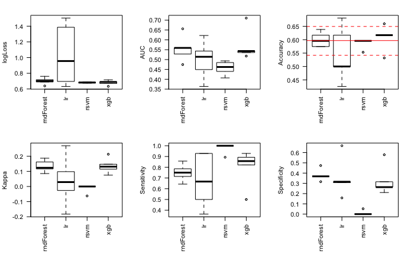

```r
source('~/ncr_notebooks/baseline_prediction/src/do_metrics_plots.R')
```

```r
sink()
```

And removing subjects with NA:

```r
ldata = ldata_orig
groups = groups_orig
keep_me = rowSums(is.na(ldata)) == 0
ldata = ldata[keep_me, ]
groups = groups[keep_me]
root_fname = '~/tmp/CPT_NAremoved_NVvsADHD'
sink(sprintf('%s.log', root_fname), append=FALSE, split=TRUE)
run_models = c('rndForest', 'lr', 'rsvm', 'xgb') # c('rndForest', 'lr', 'lsvm', 'rsvm', 'xgb', 'gbm')
inTrain = createDataPartition(y = groups,
                              times= nsplits,
                              p=train_test_ratio)
default_preproc = c("center", 'scale')
default_options = c()
ctrl_cv <- trainControl(method = "repeatedcv",
                        number = ncv,
                        repeats = nrepeatcv,
                        classProbs = TRUE,
                        returnData = FALSE,
                        summaryFunction = twoClassSummary,
                        preProcOptions = default_options,
                        search='grid')
source('~/ncr_notebooks/baseline_prediction/src/do_classification.R')
```

```
[1] 7

Working on split 1 of 5
Running random forests
   user  system elapsed
 36.342   1.549   1.947

Running logistic regression
   user  system elapsed
  2.517   0.690   1.337

Running RBF SVM
   user  system elapsed
 67.657   3.507  14.719

Running XGBoost
   user  system elapsed
186.984   3.881  40.081

Working on split 2 of 5
Running random forests
   user  system elapsed
 76.520   2.285   2.166

Running logistic regression
   user  system elapsed
  2.681   0.727   1.430

Running RBF SVM
   user  system elapsed
 65.919   3.441  13.816

Running XGBoost
   user  system elapsed
221.034   4.053  38.619

Working on split 3 of 5
Running random forests
   user  system elapsed
 40.234   1.536   2.132
```

[output cut: 31 more lines]

```
Running random forests
   user  system elapsed
 43.269   1.694   2.329

Running logistic regression
   user  system elapsed
  3.941   1.143   1.800

Running RBF SVM
maximum number of iterations reached 1.704322e-05 1.704325e-05   user  system elapsed
 69.686   3.689  15.163

Running XGBoost
   user  system elapsed
232.942   4.114  41.420
```

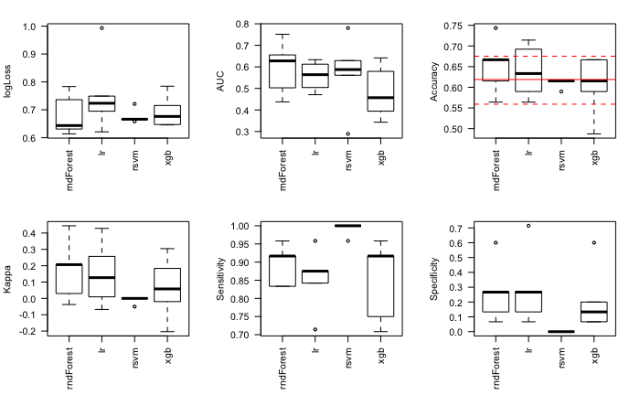

```r
source('~/ncr_notebooks/baseline_prediction/src/do_metrics_plots.R')
```

```r
sink()
```

## PCA

Let’s see if doing a PCA of the CPT components helps a bit. Like the imputation, let’s PCA the entire data, but first impute the median:

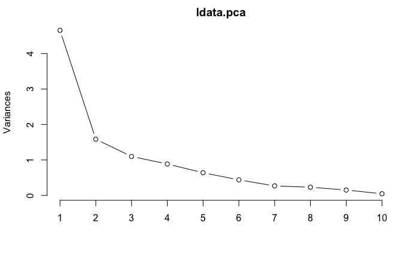

```r
ldata = ldata_orig
groups = groups_orig
preProcValues <- preProcess(ldata, method = c("medianImpute"))
ldata <- predict(preProcValues, ldata)
ldata.pca <- prcomp(ldata, center=T, scale=T)
plot(ldata.pca, type = "l")
```

```r
print(ldata.pca$sdev^2)  # these are the eignevalues
```

```
 [1] 4.65503843 1.58459435 1.09870727 0.88566113 0.63971058 0.43848964 0.26799824 0.23087062 0.15203927 0.04689048
```

The elbow seems to be at PC 2, but if we look at the eigenvalues as Philip suggested we’d go for PC 3. Let’s try both.

```r
ldata = ldata.pca$x[, 1:2]
groups = groups_orig
root_fname = '~/tmp/CPT_medianImputedPCAElbow_NVvsADHD'
sink(sprintf('%s.log', root_fname), append=FALSE, split=TRUE)
run_models = c('rndForest', 'lr', 'rsvm', 'xgb') # c('rndForest', 'lr', 'lsvm', 'rsvm', 'xgb', 'gbm')
inTrain = createDataPartition(y = groups,
                              times= nsplits,
                              p=train_test_ratio)
default_preproc = c("center", 'scale')
default_options = c()
ctrl_cv <- trainControl(method = "repeatedcv",
                        number = ncv,
                        repeats = nrepeatcv,
                        classProbs = TRUE,
                        returnData = FALSE,
                        summaryFunction = twoClassSummary,
                        preProcOptions = default_options,
                        search='grid')
source('~/ncr_notebooks/baseline_prediction/src/do_classification.R')
```

```
[1] 7

Working on split 1 of 5
Running random forests
   user  system elapsed
 38.179   0.808   1.055

Running logistic regression
   user  system elapsed
  1.989   0.680   1.242

Running RBF SVM
```

```
kernlab class prediction calculations failed; returning NAskernlab class probability calculations failed; returning NAskernlab class prediction calculations failed; returning NAskernlab class probability calculations failed; returning NAsThere were missing values in resampled performance measures.
```

```
   user  system elapsed
 97.879   2.931  26.047

Running XGBoost
   user  system elapsed
138.016   3.260  21.076

Working on split 2 of 5
Running random forests
   user  system elapsed
 20.253   0.715   1.114

Running logistic regression
   user  system elapsed
  2.273   0.783   1.345

Running RBF SVM
```

[output not shown]

```
maximum number of iterations reached 1.52956e-05 1.526475e-05   user  system elapsed
 88.432   3.265  21.728

Running XGBoost
   user  system elapsed
144.914   3.462  23.075

Working on split 3 of 5
Running random forests
   user  system elapsed
 22.085   0.746   1.179

Running logistic regression
   user  system elapsed
  2.208   0.740   1.354

Running RBF SVM
```

```
kernlab class prediction calculations failed; returning NAskernlab class probability calculations failed; returning NAsThere were missing values in resampled performance measures.
```

```
   user  system elapsed
122.451   3.236  32.619

Running XGBoost
   user  system elapsed
137.835   2.932  23.834

Working on split 4 of 5
Running random forests
   user  system elapsed
 44.308   1.194   1.163

Running logistic regression
```

```
There were missing values in resampled performance measures.
```

```
   user  system elapsed
  2.128   0.682   1.311

Running RBF SVM
   user  system elapsed
118.925   3.172  30.437

Running XGBoost
   user  system elapsed
 94.837   2.066  24.423

Working on split 5 of 5
Running random forests
   user  system elapsed
 89.383   2.283   1.197

Running logistic regression
   user  system elapsed
  1.978   0.637   1.336

Running RBF SVM
```

```
kernlab class prediction calculations failed; returning NAskernlab class probability calculations failed; returning NAsThere were missing values in resampled performance measures.
```

```
   user  system elapsed
108.290   3.217  27.376

Running XGBoost
   user  system elapsed
160.933   3.390  25.156
```

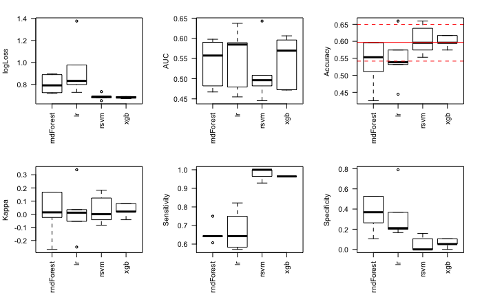

```r
source('~/ncr_notebooks/baseline_prediction/src/do_metrics_plots.R')
```

```r
sink()
```

```r
ldata = ldata.pca$x[, 1:3]
groups = groups_orig
root_fname = '~/tmp/CPT_medianImputedPCAEV1_NVvsADHD'
sink(sprintf('%s.log', root_fname), append=FALSE, split=TRUE)
run_models = c('rndForest', 'lr', 'rsvm', 'xgb') # c('rndForest', 'lr', 'lsvm', 'rsvm', 'xgb', 'gbm')
inTrain = createDataPartition(y = groups,
                              times= nsplits,
                              p=train_test_ratio)
default_preproc = c("center", 'scale')
default_options = c()
ctrl_cv <- trainControl(method = "repeatedcv",
                        number = ncv,
                        repeats = nrepeatcv,
                        classProbs = TRUE,
                        returnData = FALSE,
                        summaryFunction = twoClassSummary,
                        preProcOptions = default_options,
                        search='grid')
source('~/ncr_notebooks/baseline_prediction/src/do_classification.R')
```

```
[1] 7

Working on split 1 of 5
Running random forests
   user  system elapsed
 24.075   0.731   1.147

Running logistic regression
   user  system elapsed
  2.200   0.687   1.292

Running RBF SVM
maximum number of iterations reached 4.197926e-05 4.192969e-05   user  system elapsed
 16.333   1.497   9.153

Running XGBoost
   user  system elapsed
180.226   5.029  26.891

Working on split 2 of 5
Running random forests
   user  system elapsed
 25.407   0.752   1.196

Running logistic regression
```

```
There were missing values in resampled performance measures.
```

```
   user  system elapsed
  2.338   0.712   1.417

Running RBF SVM
   user  system elapsed
 35.143   2.594  10.677

Running XGBoost
   user  system elapsed
162.411   4.485  32.459

Working on split 3 of 5
Running random forests
   user  system elapsed
 56.193   1.517   1.402

Running logistic regression
```

```
There were missing values in resampled performance measures.
```

```
   user  system elapsed
  2.873   0.931   1.621

Running RBF SVM
   user  system elapsed
 43.583   2.643  14.345

Running XGBoost
   user  system elapsed
204.562   5.572  36.957

Working on split 4 of 5
Running random forests
   user  system elapsed
 30.762   1.021   1.540

Running logistic regression
   user  system elapsed
  3.365   1.161   1.641

Running RBF SVM
maximum number of iterations reached 1.360047e-05 1.360047e-05   user  system elapsed
 62.835   3.491  13.318

Running XGBoost
   user  system elapsed
181.868   4.965  35.455

Working on split 5 of 5
Running random forests
   user  system elapsed
 30.206   1.094   1.775

Running logistic regression
   user  system elapsed
  2.937   0.886   1.608

Running RBF SVM
   user  system elapsed
 59.704   3.720  12.487

Running XGBoost
   user  system elapsed
177.782   4.257  32.512
```

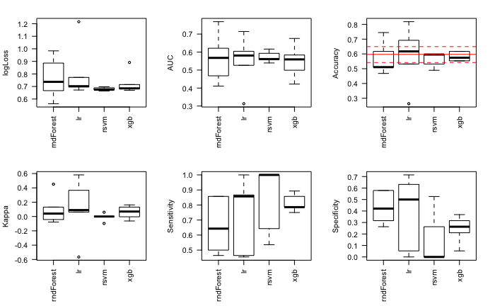

```r
source('~/ncr_notebooks/baseline_prediction/src/do_metrics_plots.R')
```

```r
sink()
```

How does it look if instead of using the medianImpute we just remove the NAs?

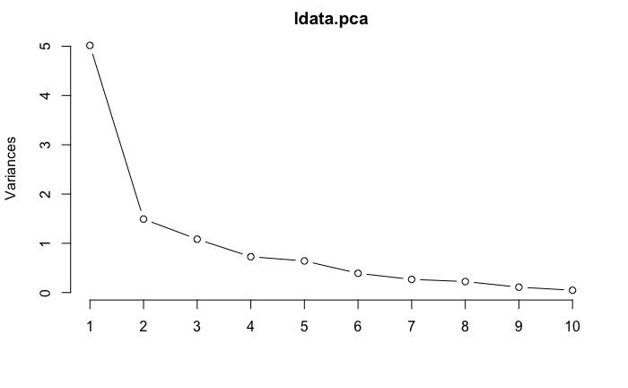

```r
ldata = ldata_orig
groups = groups_orig
keep_me = rowSums(is.na(ldata)) == 0
ldata = ldata[keep_me, ]
groups = groups[keep_me]
ldata.pca <- prcomp(ldata, center=T, scale=T)
plot(ldata.pca, type = "l")
```

```r
print(ldata.pca$sdev^2)  # these are the eignevalues
```

```
 [1] 5.01618788 1.49124363 1.08397779 0.72805144 0.64187425 0.39126229 0.26714180 0.22381592 0.10953854 0.04690647
```

Same as before, we could go for 2 or 3 PCs. Let’s try both:

```r
ldata = ldata.pca$x[, 1:2]
root_fname = '~/tmp/CPT_NAremovedPCAElbow_NVvsADHD'
sink(sprintf('%s.log', root_fname), append=FALSE, split=TRUE)
run_models = c('rndForest', 'lr', 'rsvm', 'xgb') # c('rndForest', 'lr', 'lsvm', 'rsvm', 'xgb', 'gbm')
inTrain = createDataPartition(y = groups,
                              times= nsplits,
                              p=train_test_ratio)
default_preproc = c("center", 'scale')
default_options = c()
ctrl_cv <- trainControl(method = "repeatedcv",
                        number = ncv,
                        repeats = nrepeatcv,
                        classProbs = TRUE,
                        returnData = FALSE,
                        summaryFunction = twoClassSummary,
                        preProcOptions = default_options,
                        search='grid')
source('~/ncr_notebooks/baseline_prediction/src/do_classification.R')
```

```
[1] 7

Working on split 1 of 5
Running random forests
   user  system elapsed
 29.276   0.895   1.127

Running logistic regression
   user  system elapsed
  2.237   0.820   1.483

Running RBF SVM
   user  system elapsed
 88.878   3.345  22.829

Running XGBoost
   user  system elapsed
137.166   3.605  22.170

Working on split 2 of 5
Running random forests
   user  system elapsed
 21.340   0.922   1.267

Running logistic regression
   user  system elapsed
  1.839   0.631   1.417

Running RBF SVM
   user  system elapsed
102.208   3.376  26.518

Running XGBoost
   user  system elapsed
111.693   2.709  24.723

Working on split 3 of 5
Running random forests
   user  system elapsed
 67.458   1.938   1.211
```

[output cut: 21 more lines]

```

Running RBF SVM
maximum number of iterations reached 0.00226724 0.002249443   user  system elapsed
111.686   3.418  28.454

Running XGBoost
   user  system elapsed
142.777   3.289  26.464

Working on split 5 of 5
Running random forests
   user  system elapsed
 47.977   1.339   1.264

Running logistic regression
```

```
There were missing values in resampled performance measures.
```

```
   user  system elapsed
  2.232   0.743   1.393

Running RBF SVM
   user  system elapsed
109.921   3.381  28.272

Running XGBoost
   user  system elapsed
119.254   2.705  26.218
```

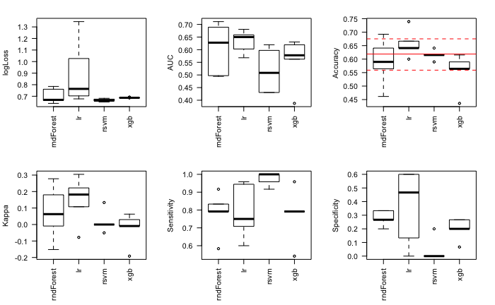

```r
source('~/ncr_notebooks/baseline_prediction/src/do_metrics_plots.R')
```

```r
sink()
```

```r
ldata = ldata.pca$x[, 1:3]
root_fname = '~/tmp/CPT_NAremovedPCAEV1_NVvsADHD'
sink(sprintf('%s.log', root_fname), append=FALSE, split=TRUE)
run_models = c('rndForest', 'lr', 'rsvm', 'xgb') # c('rndForest', 'lr', 'lsvm', 'rsvm', 'xgb', 'gbm')
inTrain = createDataPartition(y = groups,
                              times= nsplits,
                              p=train_test_ratio)
default_preproc = c("center", 'scale')
default_options = c()
ctrl_cv <- trainControl(method = "repeatedcv",
                        number = ncv,
                        repeats = nrepeatcv,
                        classProbs = TRUE,
                        returnData = FALSE,
                        summaryFunction = twoClassSummary,
                        preProcOptions = default_options,
                        search='grid')
source('~/ncr_notebooks/baseline_prediction/src/do_classification.R')
```

```
[1] 7

Working on split 1 of 5
Running random forests
   user  system elapsed
 71.045   2.066   1.214

Running logistic regression
   user  system elapsed
  2.356   0.896   1.362

Running RBF SVM
   user  system elapsed
 42.148   2.618  12.552

Running XGBoost
   user  system elapsed
183.412   5.105  29.787

Working on split 2 of 5
Running random forests
   user  system elapsed
 26.730   0.842   1.186

Running logistic regression
```

```
There were missing values in resampled performance measures.
```

```
   user  system elapsed
  2.515   0.858   1.355

Running RBF SVM
   user  system elapsed
 51.084   3.065  10.538

Running XGBoost
   user  system elapsed
164.113   5.720  29.760

Working on split 3 of 5
Running random forests
   user  system elapsed
 27.414   1.137   1.253

Running logistic regression
   user  system elapsed
  2.233   0.710   1.404

Running RBF SVM
   user  system elapsed
 28.124   2.075  11.171

Running XGBoost
   user  system elapsed
168.075   6.189  30.172

Working on split 4 of 5
Running random forests
   user  system elapsed
 54.264   1.972   1.209

Running logistic regression
   user  system elapsed
  2.173   0.672   1.322

Running RBF SVM
   user  system elapsed
 52.638   3.146  10.803

Running XGBoost
   user  system elapsed
141.887   4.938  30.815

Working on split 5 of 5
Running random forests
   user  system elapsed
 55.137   2.115   1.224

Running logistic regression
   user  system elapsed
  1.767   0.563   1.334

Running RBF SVM
   user  system elapsed
 47.373   4.632  11.709

Running XGBoost
   user  system elapsed
141.338   5.666  27.561
```

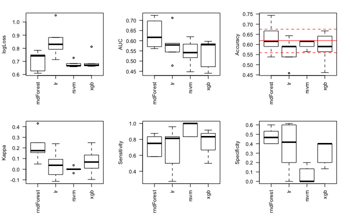

```r
source('~/ncr_notebooks/baseline_prediction/src/do_metrics_plots.R')
```

```r
sink()
```

# Decision speed

Philip says that DS_SS and SS_SS should be split from the raw bunch (DSF, DSB, SSB, SSF). Let’s try that, but also with within group PCs.

```r
conn_na = colSums(is.na(ldata)) / nrow(ldata)
phen_vars = c('DS_SS', 'SS_SS')
keep_me = c()
for (v in phen_vars) {
  keep_me = c(keep_me, which(colnames(gf) == v))
}
ldata_orig = gf[, keep_me]
```

First we try some imputation:

```r
ldata = ldata_orig
groups = groups_orig
preProcValues <- preProcess(ldata, method = c("medianImpute"))
ldata <- predict(preProcValues, ldata)
root_fname = '~/tmp/DSSS-SS_medianImputed_NVvsADHD'
sink(sprintf('%s.log', root_fname), append=FALSE, split=TRUE)
run_models = c('rndForest', 'lr', 'rsvm', 'xgb') # c('rndForest', 'lr', 'lsvm', 'rsvm', 'xgb', 'gbm')
inTrain = createDataPartition(y = groups,
                              times= nsplits,
                              p=train_test_ratio)
source('~/ncr_notebooks/baseline_prediction/src/do_classification.R')
```

```
[1] 7

Working on split 1 of 5
Running random forests
   user  system elapsed
 50.234   1.841   1.166

Running logistic regression
   user  system elapsed
  2.272   0.851   1.343

Running RBF SVM
   user  system elapsed
 65.663   4.597  14.578

Running XGBoost
   user  system elapsed
125.248   5.458  22.327

Working on split 2 of 5
Running random forests
   user  system elapsed
 20.126   1.097   1.148

Running logistic regression
   user  system elapsed
  2.084   0.667   1.421

Running RBF SVM
   user  system elapsed
 70.563   5.077  15.182

Running XGBoost
   user  system elapsed
109.274   4.851  22.550

Working on split 3 of 5
Running random forests
   user  system elapsed
 39.896   1.883   1.379

Running logistic regression
```

```
There were missing values in resampled performance measures.
```

```
   user  system elapsed
  2.287   0.742   1.405

Running RBF SVM
   user  system elapsed
 69.428   3.436  14.570

Running XGBoost
   user  system elapsed
122.734   3.577  20.974

Working on split 4 of 5
Running random forests
   user  system elapsed
 20.218   0.933   1.323

Running logistic regression
```

```
There were missing values in resampled performance measures.
```

```
   user  system elapsed
  2.061   0.729   1.596

Running RBF SVM
   user  system elapsed
 78.473   3.829  17.134

Running XGBoost
   user  system elapsed
114.891   3.348  23.268

Working on split 5 of 5
Running random forests
   user  system elapsed
 41.213   1.359   1.258

Running logistic regression
   user  system elapsed
  2.376   0.842   1.445

Running RBF SVM
   user  system elapsed
 43.881   2.704  14.261

Running XGBoost
   user  system elapsed
135.372   4.162  22.892
```

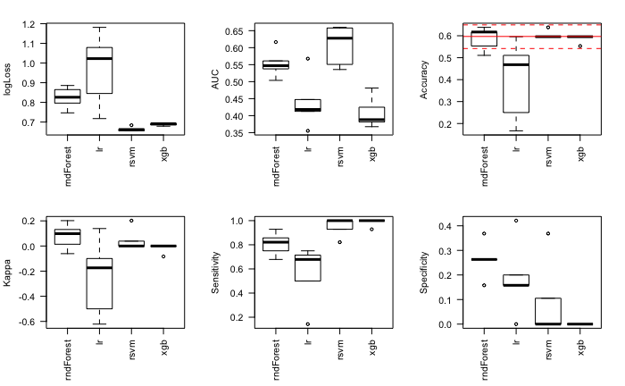

```r
source('~/ncr_notebooks/baseline_prediction/src/do_metrics_plots.R')
```

```r
sink()
```

```r
ldata = ldata_orig
groups = groups_orig
keep_me = rowSums(is.na(ldata)) == 0
ldata = ldata[keep_me, ]
groups = groups[keep_me]
root_fname = '~/tmp/DSSS-SS_NAremoved_NVvsADHD'
sink(sprintf('%s.log', root_fname), append=FALSE, split=TRUE)
run_models = c('rndForest', 'lr', 'rsvm', 'xgb') # c('rndForest', 'lr', 'lsvm', 'rsvm', 'xgb', 'gbm')
inTrain = createDataPartition(y = groups,
                              times= nsplits,
                              p=train_test_ratio)
source('~/ncr_notebooks/baseline_prediction/src/do_classification.R')
```

```
[1] 7

Working on split 1 of 5
Running random forests
   user  system elapsed
 41.009   1.307   1.149

Running logistic regression
```

```
There were missing values in resampled performance measures.
```

```
   user  system elapsed
  2.168   0.748   1.355

Running RBF SVM
   user  system elapsed
 66.816   3.559  14.232

Running XGBoost
   user  system elapsed
125.471   3.518  21.567

Working on split 2 of 5
Running random forests
   user  system elapsed
 20.424   0.851   1.170

Running logistic regression
   user  system elapsed
  1.849   0.680   1.439

Running RBF SVM
   user  system elapsed
 50.820   3.196  13.159

Running XGBoost
   user  system elapsed
121.219   3.834  23.155

Working on split 3 of 5
Running random forests
   user  system elapsed
 41.227   1.357   1.233

Running logistic regression
```

```
There were missing values in resampled performance measures.
```

```
   user  system elapsed
  2.189   0.769   1.387

Running RBF SVM
   user  system elapsed
 67.731   3.396  14.891

Running XGBoost
   user  system elapsed
128.683   3.459  21.839

Working on split 4 of 5
Running random forests
   user  system elapsed
 20.500   0.744   1.199

Running logistic regression
   user  system elapsed
  2.142   0.724   1.362

Running RBF SVM
   user  system elapsed
 62.817   3.364  13.211

Running XGBoost
   user  system elapsed
112.400   3.004  22.869

Working on split 5 of 5
Running random forests
   user  system elapsed
 41.607   1.233   1.200

Running logistic regression
   user  system elapsed
  2.141   0.681   1.352

Running RBF SVM
   user  system elapsed
 70.672   3.303  15.054

Running XGBoost
   user  system elapsed
118.088   3.117  24.335
```

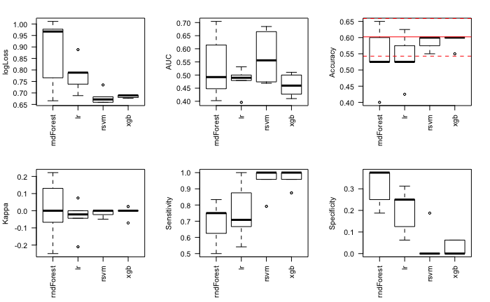

```r
source('~/ncr_notebooks/baseline_prediction/src/do_metrics_plots.R')
```

```r
sink()
```

Let’s run the raw variables now:

```r
phen_vars = c('DSF_raw', 'DSB_raw', 'SSB_raw', 'SSF_raw')
keep_me = c()
for (v in phen_vars) {
  keep_me = c(keep_me, which(colnames(gf) == v))
}
ldata_orig = gf[, keep_me]
```

```r
ldata = ldata_orig
groups = groups_orig
preProcValues <- preProcess(ldata, method = c("medianImpute"))
ldata <- predict(preProcValues, ldata)
root_fname = '~/tmp/DS-raw_medianImputed_NVvsADHD'
sink(sprintf('%s.log', root_fname), append=FALSE, split=TRUE)
run_models = c('rndForest', 'lr', 'rsvm', 'xgb') # c('rndForest', 'lr', 'lsvm', 'rsvm', 'xgb', 'gbm')
inTrain = createDataPartition(y = groups,
                              times= nsplits,
                              p=train_test_ratio)
source('~/ncr_notebooks/baseline_prediction/src/do_classification.R')
```

```
[1] 7

Working on split 1 of 5
Running random forests
   user  system elapsed
 43.919   1.438   1.545

Running logistic regression
```

```
There were missing values in resampled performance measures.
```

```
   user  system elapsed
  5.024   1.718   1.591

Running RBF SVM
   user  system elapsed
 52.835   2.522  15.827

Running XGBoost
   user  system elapsed
195.558   4.919  29.549

Working on split 2 of 5
Running random forests
   user  system elapsed
 29.360   1.136   1.594

Running logistic regression
```

```
There were missing values in resampled performance measures.
```

```
   user  system elapsed
  2.846   0.958   1.446

Running RBF SVM
   user  system elapsed
 62.993   3.586  12.453

Running XGBoost
   user  system elapsed
164.303   3.679  28.828

Working on split 3 of 5
Running random forests
   user  system elapsed
 29.420   1.222   1.689

Running logistic regression
   user  system elapsed
  2.403   0.868   1.511

Running RBF SVM
maximum number of iterations reached -0.0007672231 -0.0007685541   user  system elapsed
 43.246   2.822  13.168

Running XGBoost
   user  system elapsed
194.042   5.398  31.639

Working on split 4 of 5
Running random forests
   user  system elapsed
 28.760   0.905   1.580

Running logistic regression
```

```
There were missing values in resampled performance measures.
```

```
   user  system elapsed
  4.411   1.310   1.531

Running RBF SVM
   user  system elapsed
 64.066   3.696  12.658

Running XGBoost
   user  system elapsed
164.872   3.806  28.660

Working on split 5 of 5
Running random forests
   user  system elapsed
 27.853   0.900   1.580

Running logistic regression
```

```
There were missing values in resampled performance measures.
```

```
   user  system elapsed
  3.708   1.151   1.409

Running RBF SVM
   user  system elapsed
 41.285   2.624  11.979

Running XGBoost
   user  system elapsed
178.316   4.601  27.673
```

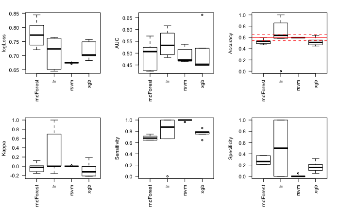

```r
source('~/ncr_notebooks/baseline_prediction/src/do_metrics_plots.R')
```

```r
sink()
```

```r
ldata = ldata_orig
groups = groups_orig
keep_me = rowSums(is.na(ldata)) == 0
ldata = ldata[keep_me, ]
groups = groups[keep_me]
root_fname = '~/tmp/DS-raw_NAremoved_NVvsADHD'
sink(sprintf('%s.log', root_fname), append=FALSE, split=TRUE)
run_models = c('rndForest', 'lr', 'rsvm', 'xgb') # c('rndForest', 'lr', 'lsvm', 'rsvm', 'xgb', 'gbm')
inTrain = createDataPartition(y = groups,
                              times= nsplits,
                              p=train_test_ratio)
source('~/ncr_notebooks/baseline_prediction/src/do_classification.R')
```

```
[1] 7

Working on split 1 of 5
Running random forests
   user  system elapsed
 27.933   1.135   1.360

Running logistic regression
   user  system elapsed
  2.409   0.946   1.277

Running RBF SVM
   user  system elapsed
 42.827   2.756   8.567

Running XGBoost
   user  system elapsed
127.204   3.283  22.185

Working on split 2 of 5
Running random forests
   user  system elapsed
 22.636   0.967   1.483

Running logistic regression
   user  system elapsed
  3.329   1.125   1.395

Running RBF SVM
   user  system elapsed
 47.233   3.242   9.229

Running XGBoost
   user  system elapsed
133.597   3.394  23.319

Working on split 3 of 5
Running random forests
   user  system elapsed
 23.624   0.984   1.496

Running logistic regression
   user  system elapsed
  3.361   1.138   1.413

Running RBF SVM
   user  system elapsed
 33.301   2.454   9.662

Running XGBoost
   user  system elapsed
161.423   4.322  25.587

Working on split 4 of 5
Running random forests
   user  system elapsed
 26.492   1.185   1.484

Running logistic regression
```

```
There were missing values in resampled performance measures.
```

```
   user  system elapsed
  2.283   0.892   1.395

Running RBF SVM
   user  system elapsed
 47.836   3.249   9.626

Running XGBoost
   user  system elapsed
148.902   3.513  26.085

Working on split 5 of 5
Running random forests
   user  system elapsed
 26.022   1.004   1.514

Running logistic regression
   user  system elapsed
  3.308   1.172   1.500

Running RBF SVM
   user  system elapsed
 28.990   2.221  11.074

Running XGBoost
   user  system elapsed
183.613   5.197  27.881
```

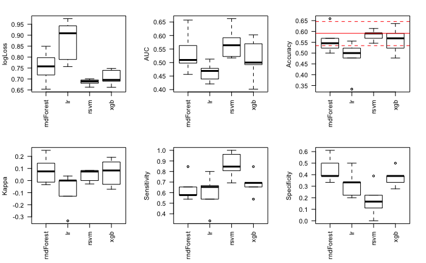

```r
source('~/ncr_notebooks/baseline_prediction/src/do_metrics_plots.R')
```

```r
sink()
```

What if we apply the PCA idea to the raw set of variables:

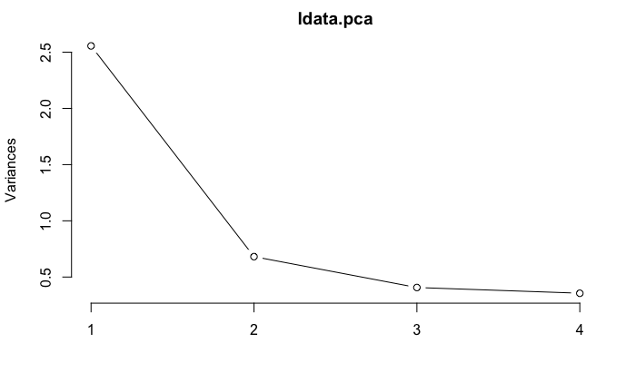

```r
ldata = ldata_orig
groups = groups_orig
preProcValues <- preProcess(ldata, method = c("medianImpute"))
ldata <- predict(preProcValues, ldata)
ldata.pca <- prcomp(ldata, center=T, scale=T)
plot(ldata.pca, type = "l")
```

```r
print(ldata.pca$sdev^2)  # these are the eignevalues
```

```
[1] 2.5558192 0.6815639 0.4068209 0.3557960
```

Here we have the inverted scenario: even though the elbow is at 2, the eigen values point to 1. Again, we try both:

```r
ldata = ldata.pca$x[, 1:2]
root_fname = '~/tmp/DS-raw_medianImputePCAElbow_NVvsADHD'
sink(sprintf('%s.log', root_fname), append=FALSE, split=TRUE)
run_models = c('rndForest', 'lr', 'rsvm', 'xgb') # c('rndForest', 'lr', 'lsvm', 'rsvm', 'xgb', 'gbm')
inTrain = createDataPartition(y = groups,
                              times= nsplits,
                              p=train_test_ratio)
default_preproc = c("center", 'scale')
default_options = c()
ctrl_cv <- trainControl(method = "repeatedcv",
                        number = ncv,
                        repeats = nrepeatcv,
                        classProbs = TRUE,
                        returnData = FALSE,
                        summaryFunction = twoClassSummary,
                        preProcOptions = default_options,
                        search='grid')
source('~/ncr_notebooks/baseline_prediction/src/do_classification.R')
```

```
[1] 7

Working on split 1 of 5
Running random forests
   user  system elapsed
  2.501   0.879   1.132

Running logistic regression
```

```
There were missing values in resampled performance measures.
```

```
   user  system elapsed
  2.291   0.879   1.302

Running RBF SVM
```

```
kernlab class prediction calculations failed; returning NAskernlab class probability calculations failed; returning NAskernlab class prediction calculations failed; returning NAskernlab class probability calculations failed; returning NAsThere were missing values in resampled performance measures.
```

```
   user  system elapsed
102.750   3.135  27.054

Running XGBoost
   user  system elapsed
145.119   3.551  22.975

Working on split 2 of 5
Running random forests
   user  system elapsed
 21.436   0.755   1.163

Running logistic regression
   user  system elapsed
  2.476   0.752   1.521

Running RBF SVM
   user  system elapsed
124.584   3.608  32.901

Running XGBoost
   user  system elapsed
155.335   3.952  24.676

Working on split 3 of 5
Running random forests
   user  system elapsed
 22.231   0.866   1.338

Running logistic regression
```

```
There were missing values in resampled performance measures.
```

```
   user  system elapsed
  2.669   0.801   1.637

Running RBF SVM
   user  system elapsed
146.497   4.147  39.597

Running XGBoost
   user  system elapsed
150.944   3.683  26.142

Working on split 4 of 5
Running random forests
   user  system elapsed
 47.376   1.449   1.452

Running logistic regression
   user  system elapsed
  2.510   0.820   1.446

Running RBF SVM
```

```
kernlab class prediction calculations failed; returning NAskernlab class probability calculations failed; returning NAsThere were missing values in resampled performance measures.
```

```
maximum number of iterations reached 0.0003075398 0.0003071835   user  system elapsed
139.979   3.889  38.949

Running XGBoost
   user  system elapsed
181.293   4.380  28.160

Working on split 5 of 5
Running random forests
   user  system elapsed
 25.800   0.962   1.553

Running logistic regression
```

```
There were missing values in resampled performance measures.
```

```
   user  system elapsed
  3.798   1.391   1.754

Running RBF SVM
maximum number of iterations reached -0.0002594461 -0.000260002   user  system elapsed
141.184   3.754  37.340

Running XGBoost
   user  system elapsed
159.746   3.727  28.728
```

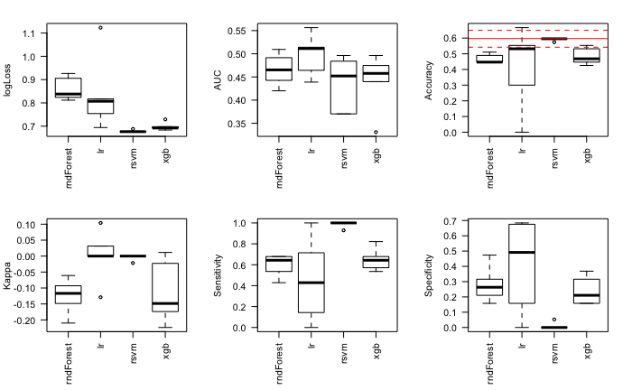

```r
source('~/ncr_notebooks/baseline_prediction/src/do_metrics_plots.R')
```

```r
sink()
```

```r
ldata = as.data.frame(ldata.pca$x[, 1])
root_fname = '~/tmp/DS-raw_medianImputePCAEV1_NVvsADHD'
sink(sprintf('%s.log', root_fname), append=FALSE, split=TRUE)
run_models = c('rndForest', 'lr') # c('rndForest', 'lr', 'lsvm', 'rsvm', 'xgb', 'gbm')
inTrain = createDataPartition(y = groups,
                              times= nsplits,
                              p=train_test_ratio)
default_preproc = c("center", 'scale')
default_options = c()
ctrl_cv <- trainControl(method = "repeatedcv",
                        number = ncv,
                        repeats = nrepeatcv,
                        classProbs = TRUE,
                        returnData = FALSE,
                        summaryFunction = twoClassSummary,
                        preProcOptions = default_options,
                        search='grid')
source('~/ncr_notebooks/baseline_prediction/src/do_classification.R')
```

```
[1] 7

Working on split 1 of 5
Running random forests
   user  system elapsed
 51.341   1.465   1.166

Running logistic regression
   user  system elapsed
  2.214   0.712   1.351

Working on split 2 of 5
Running random forests
   user  system elapsed
  2.356   0.825   1.063

Running logistic regression
   user  system elapsed
  2.155   0.691   1.334

Working on split 3 of 5
Running random forests
   user  system elapsed
  2.455   0.829   1.137

Running logistic regression
   user  system elapsed
  2.275   0.710   1.383

Working on split 4 of 5
Running random forests
   user  system elapsed
  2.751   0.895   1.162

Running logistic regression
   user  system elapsed
  2.025   0.652   1.358

Working on split 5 of 5
Running random forests
   user  system elapsed
  2.467   0.811   1.114

Running logistic regression
   user  system elapsed
  3.042   1.069   1.435
```

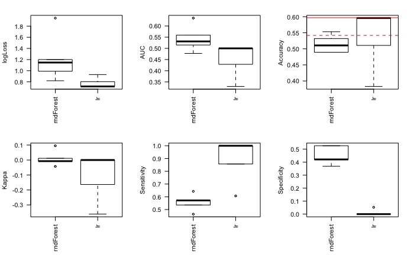

```r
source('~/ncr_notebooks/baseline_prediction/src/do_metrics_plots.R')
```

```r
sink()
```

And like before, we do the same after removing subjects:

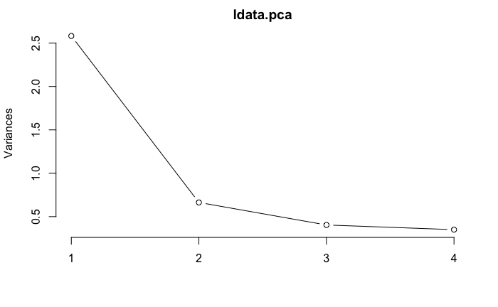

```r
ldata = ldata_orig
groups = groups_orig
keep_me = rowSums(is.na(ldata)) == 0
ldata = ldata[keep_me, ]
groups = groups[keep_me]
ldata.pca <- prcomp(ldata, center=T, scale=T)
plot(ldata.pca, type = "l")
```

```r
print(ldata.pca$sdev^2)  # these are the eignevalues
```

```
[1] 2.5823982 0.6637047 0.4039430 0.3499541
```

```r
ldata = ldata.pca$x[, 1:2]
root_fname = '~/tmp/DS-raw_NAremovedPCAElbow_NVvsADHD'
sink(sprintf('%s.log', root_fname), append=FALSE, split=TRUE)
run_models = c('rndForest', 'lr', 'rsvm', 'xgb') # c('rndForest', 'lr', 'lsvm', 'rsvm', 'xgb', 'gbm')
inTrain = createDataPartition(y = groups,
                              times= nsplits,
                              p=train_test_ratio)
default_preproc = c("center", 'scale')
default_options = c()
ctrl_cv <- trainControl(method = "repeatedcv",
                        number = ncv,
                        repeats = nrepeatcv,
                        classProbs = TRUE,
                        returnData = FALSE,
                        summaryFunction = twoClassSummary,
                        preProcOptions = default_options,
                        search='grid')
source('~/ncr_notebooks/baseline_prediction/src/do_classification.R')
```

```
[1] 7

Working on split 1 of 5
Running random forests
   user  system elapsed
  2.212   0.618   1.192

Running logistic regression
```

```
There were missing values in resampled performance measures.
```

```
   user  system elapsed
  1.830   0.652   1.434

Running RBF SVM
   user  system elapsed
105.068   3.408  28.714

Running XGBoost
   user  system elapsed
160.566   3.998  26.031

Working on split 2 of 5
Running random forests
   user  system elapsed
 23.887   0.863   1.425

Running logistic regression
```

```
There were missing values in resampled performance measures.
```

```
   user  system elapsed
  2.428   0.797   1.508

Running RBF SVM
   user  system elapsed
107.203   3.464  27.864

Running XGBoost
   user  system elapsed
141.560   3.514  26.881

Working on split 3 of 5
Running random forests
   user  system elapsed
 47.654   1.447   1.412

Running logistic regression
   user  system elapsed
  2.557   0.853   1.688

Running RBF SVM
```

```
kernlab class prediction calculations failed; returning NAskernlab class probability calculations failed; returning NAsThere were missing values in resampled performance measures.
```

```
maximum number of iterations reached 0.0001901184 0.0001901165   user  system elapsed
131.820   3.645  34.269

Running XGBoost
   user  system elapsed
146.862   3.229  25.863

Working on split 4 of 5
Running random forests
   user  system elapsed
 47.223   1.308   1.211

Running logistic regression
   user  system elapsed
  2.680   0.971   1.417

Running RBF SVM
   user  system elapsed
114.042   3.383  29.472

Running XGBoost
   user  system elapsed
162.436   3.825  25.452

Working on split 5 of 5
Running random forests
   user  system elapsed
 24.054   0.791   1.276

Running logistic regression
   user  system elapsed
  2.205   0.694   1.382

Running RBF SVM
   user  system elapsed
124.955   3.527  34.404

Running XGBoost
   user  system elapsed
147.367   3.367  26.205
```

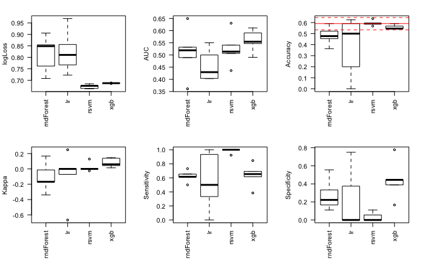

```r
source('~/ncr_notebooks/baseline_prediction/src/do_metrics_plots.R')
```

```r
sink()
```

```r
ldata = as.data.frame(ldata.pca$x[, 1])
root_fname = '~/tmp/DS-raw_NAremovedPCAEV1_NVvsADHD'
sink(sprintf('%s.log', root_fname), append=FALSE, split=TRUE)
run_models = c('rndForest', 'lr') # c('rndForest', 'lr', 'lsvm', 'rsvm', 'xgb', 'gbm')
inTrain = createDataPartition(y = groups,
                              times= nsplits,
                              p=train_test_ratio)
default_preproc = c("center", 'scale')
default_options = c()
ctrl_cv <- trainControl(method = "repeatedcv",
                        number = ncv,
                        repeats = nrepeatcv,
                        classProbs = TRUE,
                        returnData = FALSE,
                        summaryFunction = twoClassSummary,
                        preProcOptions = default_options,
                        search='grid')
source('~/ncr_notebooks/baseline_prediction/src/do_classification.R')
```

```
[1] 7

Working on split 1 of 5
Running random forests
   user  system elapsed
 47.806   1.381   1.108

Running logistic regression
   user  system elapsed
  3.117   1.115   1.454

Working on split 2 of 5
Running random forests
   user  system elapsed
  1.922   0.515   1.114

Running logistic regression
   user  system elapsed
  2.034   0.647   1.412

Working on split 3 of 5
Running random forests
   user  system elapsed
  2.629   0.866   1.309

Running logistic regression
   user  system elapsed
  2.444   0.775   1.562

Working on split 4 of 5
Running random forests
   user  system elapsed
  2.700   0.904   1.280

Running logistic regression
   user  system elapsed
  2.254   0.724   1.399

Working on split 5 of 5
Running random forests
   user  system elapsed
  2.399   0.784   1.141

Running logistic regression
   user  system elapsed
  2.130   0.686   1.357
```

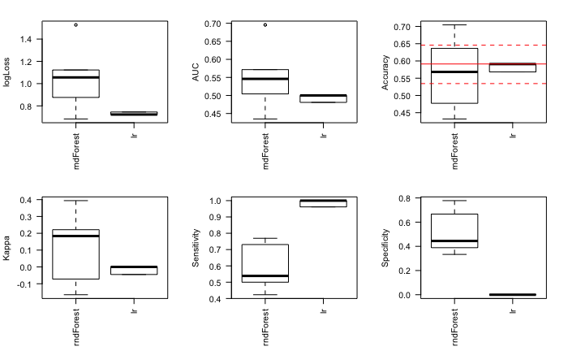

```r
source('~/ncr_notebooks/baseline_prediction/src/do_metrics_plots.R')
```

```r
sink()
```